# DS6306 Case Study 02

Will Rogers

8/7/2021

# Introduction

We have been tasked with using data science to identify trends in that lead to attrition and then fit a model that will have success in identifying individuals that are likely to leave the company. We have been given a dataset that contains employee information to conduct our analysis on.

# EDA

A summary of the variables in our data set can been seen below. Our first step will be to clean the data into a more usable format.

```
##        ID             Age        Attrition           BusinessTravel
##  Min.   :  1.0   Min.   :18.00   No :730   Non-Travel       : 94
##  1st Qu.:218.2   1st Qu.:30.00   Yes:140   Travel_Frequently:158
##  Median :435.5   Median :35.00             Travel_Rarely    :618
##  Mean   :435.5   Mean   :36.83
##  3rd Qu.:652.8   3rd Qu.:43.00
##  Max.   :870.0   Max.   :60.00
##
##    DailyRate                       Department  DistanceFromHome   Education
##  Min.   : 103.0   Human Resources       : 35   Min.   : 1.000   Min.   :1.000
##  1st Qu.: 472.5   Research & Development:562   1st Qu.: 2.000   1st Qu.:2.000
##  Median : 817.5   Sales                 :273   Median : 7.000   Median :3.000
##  Mean   : 815.2                                Mean   : 9.339   Mean   :2.901
##  3rd Qu.:1165.8                                3rd Qu.:14.000   3rd Qu.:4.000
##  Max.   :1499.0                                Max.   :29.000   Max.   :5.000
##
##           EducationField EmployeeCount EmployeeNumber   EnvironmentSatisfaction
##  Human Resources : 15    Min.   :1     Min.   :   1.0   Min.   :1.000
##  Life Sciences   :358    1st Qu.:1     1st Qu.: 477.2   1st Qu.:2.000
##  Marketing       :100    Median :1     Median :1039.0   Median :3.000
##  Medical         :270    Mean   :1     Mean   :1029.8   Mean   :2.701
##  Other           : 52    3rd Qu.:1     3rd Qu.:1561.5   3rd Qu.:4.000
##  Technical Degree: 75    Max.   :1     Max.   :2064.0   Max.   :4.000
##
##     Gender      HourlyRate     JobInvolvement     JobLevel
##  Female:354   Min.   : 30.00   Min.   :1.000   Min.   :1.000
##  Male  :516   1st Qu.: 48.00   1st Qu.:2.000   1st Qu.:1.000
##               Median : 66.00   Median :3.000   Median :2.000
##               Mean   : 65.61   Mean   :2.723   Mean   :2.039
##               3rd Qu.: 83.00   3rd Qu.:3.000   3rd Qu.:3.000
##               Max.   :100.00   Max.   :4.000   Max.   :5.000
##
##                       JobRole    JobSatisfaction  MaritalStatus MonthlyIncome
##  Sales Executive          :200   Min.   :1.000   Divorced:191   Min.   : 1081
##  Research Scientist       :172   1st Qu.:2.000   Married :410   1st Qu.: 2840
##  Laboratory Technician    :153   Median :3.000   Single  :269   Median : 4946
##  Manufacturing Director   : 87   Mean   :2.709                  Mean   : 6390
##  Healthcare Representative: 76   3rd Qu.:4.000                  3rd Qu.: 8182
##  Sales Representative     : 53   Max.   :4.000                  Max.   :19999
##  (Other)                  :129
```

[output cut: 17 more lines]

```
##  Min.   : 0.00     Min.   :0.000         Min.   :1.000   Min.   : 0.000
##  1st Qu.: 6.00     1st Qu.:2.000         1st Qu.:2.000   1st Qu.: 3.000
##  Median :10.00     Median :3.000         Median :3.000   Median : 5.000
##  Mean   :11.05     Mean   :2.832         Mean   :2.782   Mean   : 6.962
##  3rd Qu.:15.00     3rd Qu.:3.000         3rd Qu.:3.000   3rd Qu.:10.000
##  Max.   :40.00     Max.   :6.000         Max.   :4.000   Max.   :40.000
##
##  YearsInCurrentRole YearsSinceLastPromotion YearsWithCurrManager
##  Min.   : 0.000     Min.   : 0.000          Min.   : 0.00
##  1st Qu.: 2.000     1st Qu.: 0.000          1st Qu.: 2.00
##  Median : 3.000     Median : 1.000          Median : 3.00
##  Mean   : 4.205     Mean   : 2.169          Mean   : 4.14
##  3rd Qu.: 7.000     3rd Qu.: 3.000          3rd Qu.: 7.00
##  Max.   :18.000     Max.   :15.000          Max.   :17.00
##
```

## Cleaning Data

The first step taken to clean that data was to check how many of the fields candidates to use at all. This means removing variables that only have one value or are unique for every single entry. The variables that were removed from the data set and the number of unique values they contain can be seen below. As a reminder the data set contains 870 observations

```
##                sel_col
## EmployeeCount        1
## Over18               1
## StandardHours        1
## ID                 870
## EmployeeNumber     870
```

## Transformations

The only transform deemed necessary was to put MonthlyIncome on the log scale since it was heavily right skewed.

## Attrition Classification

### Balance of Data

Ideally, we would like to have balanced data during classification problems. The more imbalanced the data is, the more likely we will need to address it. A plot of the balance the Attrition variable is below.

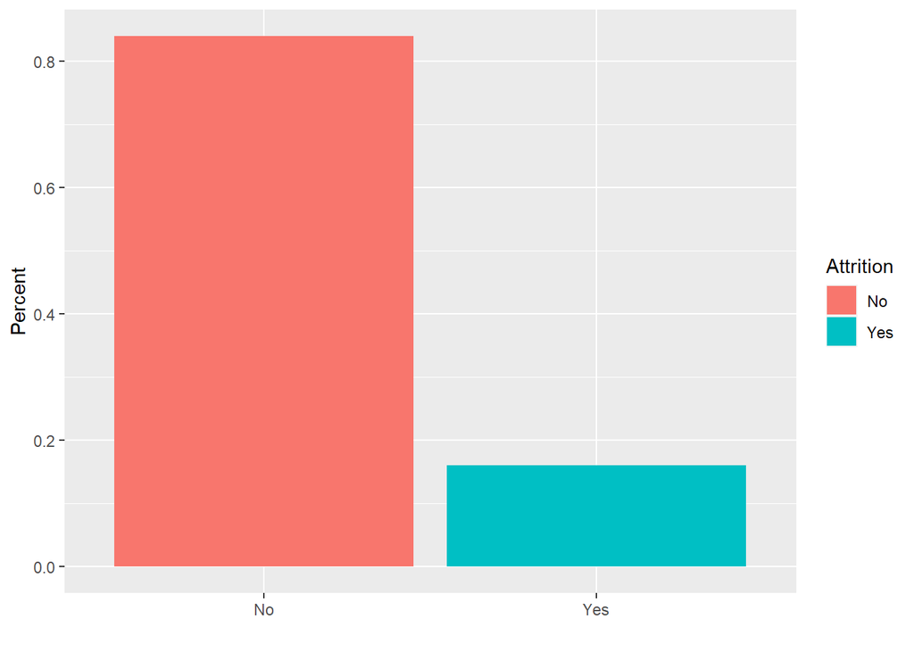

### Principal Component Analysis

In an effort reduce the data a find important trends, a PCA is performed on the data. This will help us to find the most important combination of variables that explain the variance in the data. We can then reduce the data by taking a threshold value for the amount of variance we want to explain.

#### Number of Axes to Use

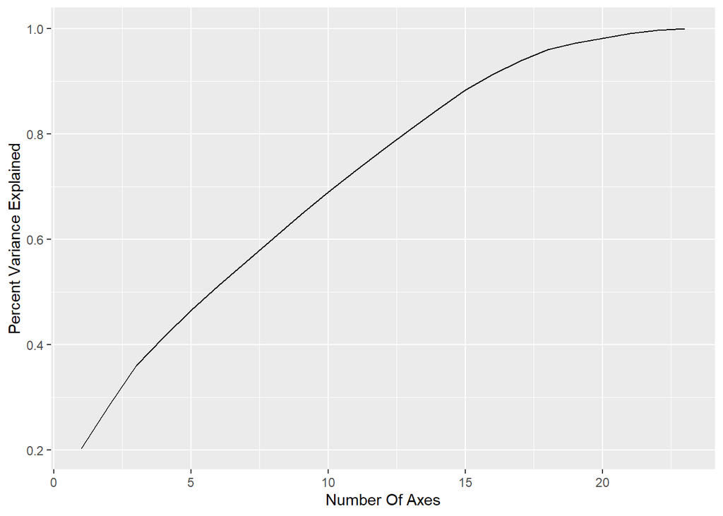

#### Top Three Axes

One of the primary objectives of this investigation is to identify three important factors that lead to attrition according to our data set. The top three axes from our PCA are below with each sorted by the most influential variables in that axes.

##### PC1

```
##                                  Axes
## TotalWorkingYears         0.403865833
## YearsAtCompany            0.391116216
## JobLevel                  0.374347494
## MonthlyIncome             0.371171338
## YearsInCurrentRole        0.344955787
## YearsWithCurrManager      0.332109083
## YearsSinceLastPromotion   0.301073767
## Age                       0.264843355
## Education                 0.088711388
## PercentSalaryHike        -0.046989059
## NumCompaniesWorked        0.043772093
## PerformanceRating        -0.032203763
## StockOptionLevel          0.028825742
## MonthlyRate               0.025976087
## WorkLifeBalance           0.022911759
## TrainingTimesLastYear    -0.021475589
## JobSatisfaction          -0.015027843
## DailyRate                -0.008408220
## HourlyRate                0.007078095
## EnvironmentSatisfaction  -0.005760477
## JobInvolvement           -0.005141803
## RelationshipSatisfaction -0.002875741
## DistanceFromHome         -0.000903502
```

##### PC2

```
##                                  Axes
## NumCompaniesWorked       -0.461913535
## Age                      -0.332290154
## YearsWithCurrManager      0.310487419
## YearsInCurrentRole        0.303672772
## PerformanceRating         0.303127445
## PercentSalaryHike         0.278663017
## YearsAtCompany            0.271381294
## YearsSinceLastPromotion   0.229552802
## MonthlyIncome            -0.209416831
## JobLevel                 -0.208294246
## Education                -0.191456272
## TotalWorkingYears        -0.185692685
## TrainingTimesLastYear     0.088482380
## JobSatisfaction           0.086831850
## MonthlyRate              -0.078114214
## DailyRate                -0.075678500
## HourlyRate               -0.053850336
## WorkLifeBalance           0.040943121
## JobInvolvement           -0.025314988
## RelationshipSatisfaction -0.023943660
## StockOptionLevel         -0.016251696
## EnvironmentSatisfaction   0.009020844
## DistanceFromHome         -0.002223392
```

##### PC3

```
##                                 Axes
## PercentSalaryHike         0.64340366
## PerformanceRating         0.63155653
## NumCompaniesWorked        0.19332145
## Age                       0.17011933
## YearsSinceLastPromotion  -0.12354820
## MonthlyIncome             0.12088941
## JobLevel                  0.11779760
## YearsWithCurrManager     -0.11365758
## TotalWorkingYears         0.10636969
## YearsAtCompany           -0.10579339
## Education                 0.10099672
## YearsInCurrentRole       -0.08926912
## DistanceFromHome          0.08890253
## RelationshipSatisfaction -0.06359539
## TrainingTimesLastYear    -0.06176498
## MonthlyRate               0.04690199
## DailyRate                 0.04340550
## JobInvolvement            0.03955440
## JobSatisfaction          -0.03867140
## HourlyRate                0.01794755
## EnvironmentSatisfaction  -0.01143978
## StockOptionLevel          0.01104695
## WorkLifeBalance           0.00486867
```

##### Axes Explanation

PC2 is roughly the opposite of PC1. The employee who is young and ambitious, but has not found something they are content with will score high on this axis.

PC3 contains variables that are related to overall job satisfaction. It is not a large stretch to say that employees are more satisfied if they get good performance ratings and larger salary increases.

##### Axes as Classifier

Something that will help determine the kind of classifier we should use for this data is how well the numerical data alone is suited towards this kind of task. A method of this is plotting the first two PCA axes against each other and looking for separation in the classification of interest. This plot, for the attrition data, can be seen below.

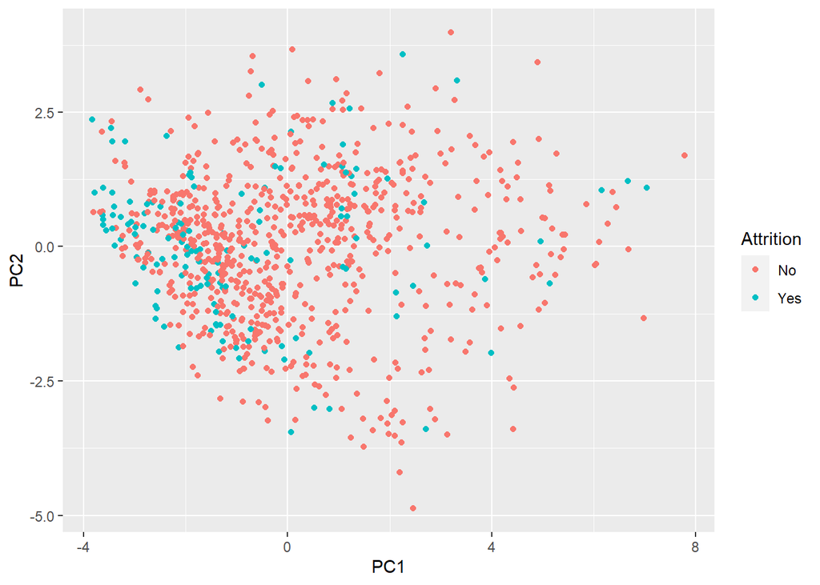

Based on this graph, there is not clear separation using the numerical data alone. There does appear to be tendency for ‘Yes’ attrition towards the negative value of PC1 but not enough to be considered clear separation.

### Categorical Analysis

Since PCA only works on numerical data, the categorical variables are examined separately. The method used to find the important categorical variables was to calculate the odds ratio for Attrition of ‘Yes’ to ‘No’ for each level of every variable. The full list of these values can be seen below.

```
##         BusinessTravel_Non-Travel  BusinessTravel_Travel_Frequently
##                         0.6910499                         1.4837398
##      BusinessTravel_Travel_Rarely        Department_Human Resources
##                         0.9353871                         1.0788177
## Department_Research & Development                  Department_Sales
##                         0.8030214                         1.4375834
##    EducationField_Human Resources      EducationField_Life Sciences
##                         1.8961039                         0.9060890
##          EducationField_Marketing            EducationField_Medical
##                         1.3035714                         0.8280196
##              EducationField_Other   EducationField_Technical Degree
##                         1.0913621                         1.5283251
##                     Gender_Female                       Gender_Male
##                         0.9181300                         1.0574426
## JobRole_Healthcare Representative           JobRole_Human Resources
##                         0.6134454                         1.4897959
##     JobRole_Laboratory Technician                   JobRole_Manager
##                         1.2717770                         0.4437690
##    JobRole_Manufacturing Director         JobRole_Research Director
##                         0.1226891                         0.1042857
##        JobRole_Research Scientist           JobRole_Sales Executive
##                         1.1918367                         1.0303678
##      JobRole_Sales Representative            MaritalStatus_Divorced
##                         4.3152709                         0.3495611
##             MaritalStatus_Married              MaritalStatus_Single
##                         0.8591721                         1.8341709
##                       OverTime_No                      OverTime_Yes
##                         0.5606759                         2.4252492
```

Values inside of defined threshold were then filtered out, leaving only the categorical variables with most influence on Attrition. The table below shows the remaining variables.

```
##      JobRole_Sales Representative                      OverTime_Yes
##                         4.3152709                         2.4252492
##    EducationField_Human Resources              MaritalStatus_Single
##                         1.8961039                         1.8341709
##   EducationField_Technical Degree JobRole_Healthcare Representative
##                         1.5283251                         0.6134454
##                       OverTime_No                   JobRole_Manager
##                         0.5606759                         0.4437690
##            MaritalStatus_Divorced    JobRole_Manufacturing Director
##                         0.3495611                         0.1226891
##         JobRole_Research Director
##                         0.1042857
```

Since dummy each original variable was spread out across multiple dummy variables to support the above analysis. The most important variables found above are a level of the original variable. This means that the most important variables to use in the analysis are these.

```
## [1] "EducationField" "JobRole"        "MaritalStatus"  "OverTime"
```

### Top Three Factors

Based on the EDA above our best candidates for the top three factors that lead to employee attrition come from the most influential numerical and categorical variables. As a reminder the top numerical factors are considered to be the top principal components, and the top categorical factors are the variables that showed the most influence on the odds of attrition. Given that strongest odds come from variables that are levels of JobRole with SalesRep and Manager/Directors showing the most Influence. The next most influential categorical variable is MaritalStatus which has two levels that show strong influence. The last factor is the first PC, which we have identified in this study as overall employee contentedness. In a list three important factors for employee retention are: - Contentedness - Job Role - Marital Status

# Models

Given that we have identified the importance of a few categorical variables. The model we use for prediction should be able to account for these types of variables. At this time the models under consideration were a Naive Bayes model or a KNN model. Given that KNN can only work on numerical values, the Naive Bayes model was selected as the method to build a predictive model.

## Attrition Prediction

### Naive Bayes

For comparisons sake the naive bayes approach was evaluated against four different times. 1. All Variables Untransformed 2. All Untransformed Numerical Value with Subset Categorical 3. Principal Components with All Categorical Variables 4. Principal Components with Subset Categorical

#### All Untransformed Variables

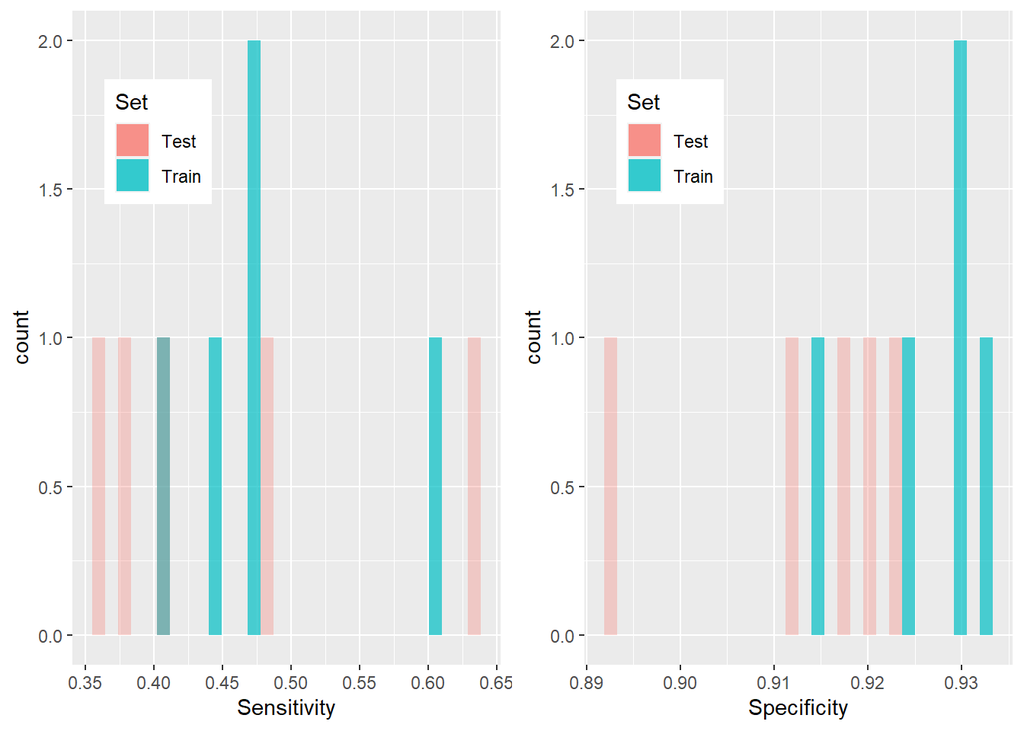

##### T-test for Passing

A t-test was used to see if the sampling of Sensitivity and Specificity was expected to be greater than 0.6 for each the test and training set.

###### Train

```
##
##  One Sample t-test
##
## data:  acc %>% filter(Set == "Train") %>% select(Sensitivity)
## t = -3.5547, df = 4, p-value = 0.9882
## alternative hypothesis: true mean is greater than 0.6
## 95 percent confidence interval:
##  0.4100138       Inf
## sample estimates:
## mean of x
## 0.4812384
```

```
##
##  One Sample t-test
##
## data:  acc %>% filter(Set == "Train") %>% select(Specificity)
## t = 101.85, df = 4, p-value = 2.786e-08
## alternative hypothesis: true mean is greater than 0.6
## 95 percent confidence interval:
##  0.9199329       Inf
## sample estimates:
## mean of x
## 0.9267723
```

###### Test

```
##
##  One Sample t-test
##
## data:  acc %>% filter(Set == "Test") %>% select(Sensitivity)
## t = -2.9906, df = 4, p-value = 0.9798
## alternative hypothesis: true mean is greater than 0.6
## 95 percent confidence interval:
##  0.3443734       Inf
## sample estimates:
## mean of x
## 0.4507589
```

```
##
##  One Sample t-test
##
## data:  acc %>% filter(Set == "Test") %>% select(Specificity)
## t = 59.283, df = 4, p-value = 2.424e-07
## alternative hypothesis: true mean is greater than 0.6
## 95 percent confidence interval:
##  0.9016194       Inf
## sample estimates:
## mean of x
## 0.9128704
```

#### All Untransformed Numerical Value with Subset Categorical

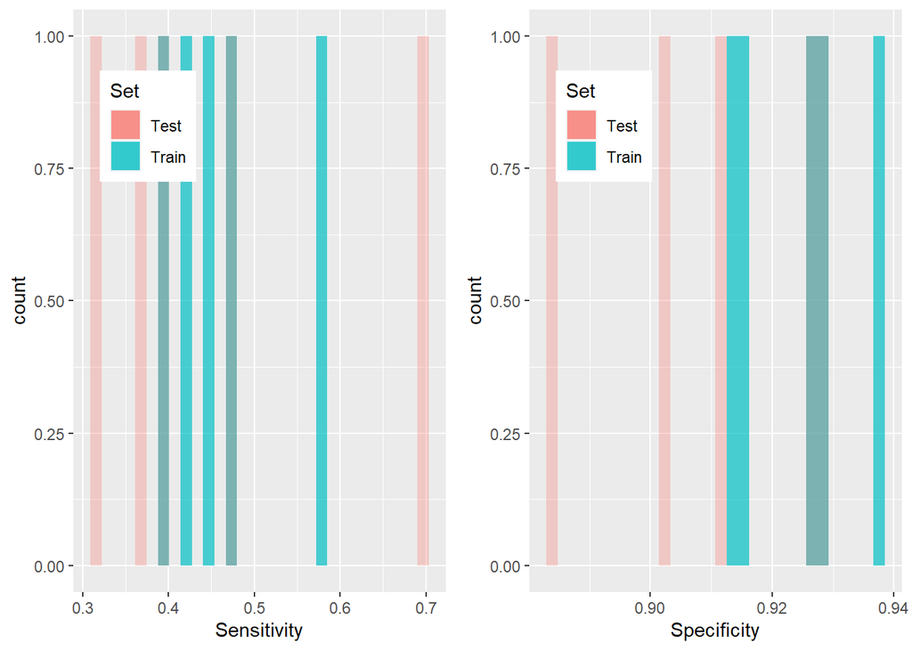

##### T-test for Passing

A t-test was used to see if the sampling of Sensitivity and Specificity was expected to be greater than 0.6 for each the test and training set.

###### Train

```
##
##  One Sample t-test
##
## data:  acc %>% filter(Set == "Train") %>% select(Sensitivity)
## t = -4.1621, df = 4, p-value = 0.9929
## alternative hypothesis: true mean is greater than 0.6
## 95 percent confidence interval:
##  0.3919485       Inf
## sample estimates:
## mean of x
## 0.4624187
```

```
##
##  One Sample t-test
##
## data:  acc %>% filter(Set == "Train") %>% select(Specificity)
## t = 71.113, df = 4, p-value = 1.172e-07
## alternative hypothesis: true mean is greater than 0.6
## 95 percent confidence interval:
##  0.9144705       Inf
## sample estimates:
## mean of x
## 0.9241891
```

###### Test

```
##
##  One Sample t-test
##
## data:  acc %>% filter(Set == "Test") %>% select(Sensitivity)
## t = -2.204, df = 4, p-value = 0.9539
## alternative hypothesis: true mean is greater than 0.6
## 95 percent confidence interval:
##  0.3060867       Inf
## sample estimates:
## mean of x
## 0.4505983
```

```
##
##  One Sample t-test
##
## data:  acc %>% filter(Set == "Test") %>% select(Specificity)
## t = 37.24, df = 4, p-value = 1.552e-06
## alternative hypothesis: true mean is greater than 0.6
## 95 percent confidence interval:
##  0.8930159       Inf
## sample estimates:
## mean of x
## 0.9108086
```

#### Principal Components with All Categorical Variables

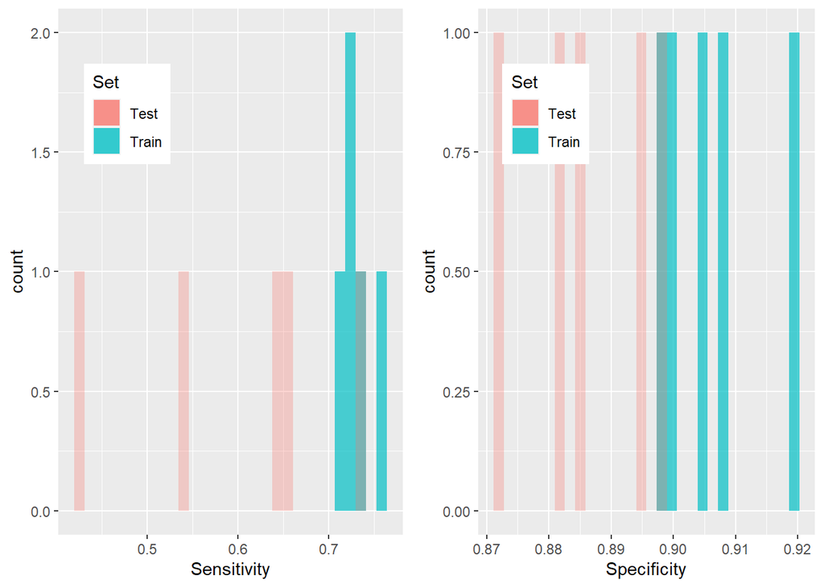

##### T-test for Passing A t-test was used to see if the sampling of Sensitivity and Specificity was expected to be greater than 0.6 for each the test and training set.

###### Train

```
##
##  One Sample t-test
##
## data:  acc %>% filter(Set == "Train") %>% select(Sensitivity)
## t = 15.863, df = 4, p-value = 4.615e-05
## alternative hypothesis: true mean is greater than 0.6
## 95 percent confidence interval:
##  0.7133586       Inf
## sample estimates:
## mean of x
## 0.7309585
```

```
##
##  One Sample t-test
##
## data:  acc %>% filter(Set == "Train") %>% select(Specificity)
## t = 80.798, df = 4, p-value = 7.032e-08
## alternative hypothesis: true mean is greater than 0.6
## 95 percent confidence interval:
##  0.8978892       Inf
## sample estimates:
## mean of x
##  0.905962
```

###### Test

```
##
##  One Sample t-test
##
## data:  acc %>% filter(Set == "Test") %>% select(Sensitivity)
## t = 0.0021737, df = 4, p-value = 0.4992
## alternative hypothesis: true mean is greater than 0.6
## 95 percent confidence interval:
##  0.4866696       Inf
## sample estimates:
## mean of x
## 0.6001157
```

```
##
##  One Sample t-test
##
## data:  acc %>% filter(Set == "Test") %>% select(Specificity)
## t = 62.336, df = 4, p-value = 1.983e-07
## alternative hypothesis: true mean is greater than 0.6
## 95 percent confidence interval:
##  0.8761086       Inf
## sample estimates:
## mean of x
## 0.8858856
```

#### Principal Components with Subset Categorical Variables

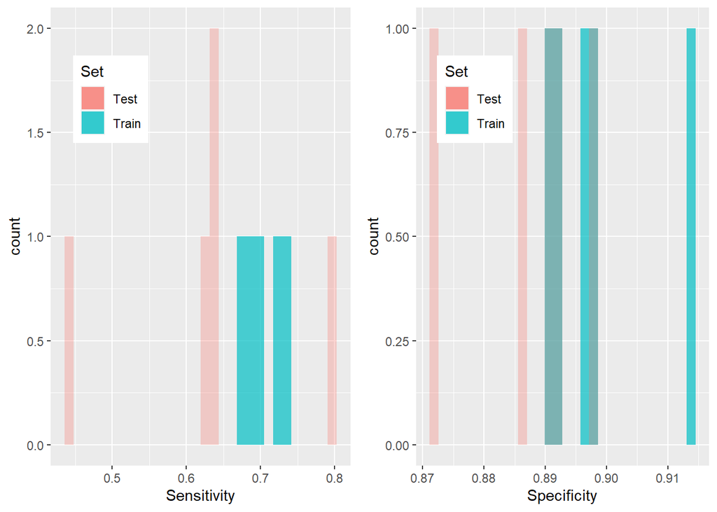

##### T-test for Passing

A t-test was used to see if the sampling of Sensitivity and Specificity was expected to be greater than 0.6 for each the test and training set.

###### Train

```
##
##  One Sample t-test
##
## data:  acc %>% filter(Set == "Train") %>% select(Sensitivity)
## t = 9.7706, df = 4, p-value = 0.0003074
## alternative hypothesis: true mean is greater than 0.6
## 95 percent confidence interval:
##  0.681643      Inf
## sample estimates:
## mean of x
## 0.7044282
```

```
##
##  One Sample t-test
##
## data:  acc %>% filter(Set == "Train") %>% select(Specificity)
## t = 70.788, df = 4, p-value = 1.193e-07
## alternative hypothesis: true mean is greater than 0.6
## 95 percent confidence interval:
##  0.8893178       Inf
## sample estimates:
## mean of x
## 0.8983014
```

###### Test

```
##
##  One Sample t-test
##
## data:  acc %>% filter(Set == "Test") %>% select(Sensitivity)
## t = 0.54007, df = 4, p-value = 0.3089
## alternative hypothesis: true mean is greater than 0.6
## 95 percent confidence interval:
##  0.5102233       Inf
## sample estimates:
## mean of x
## 0.6304603
```

```
##
##  One Sample t-test
##
## data:  acc %>% filter(Set == "Test") %>% select(Specificity)
## t = 67.629, df = 4, p-value = 1.432e-07
## alternative hypothesis: true mean is greater than 0.6
## 95 percent confidence interval:
##  0.8787642       Inf
## sample estimates:
## mean of x
## 0.8878377
```

## Salary Prediction

The final goal of this study was to predict MonthlyIncome with an RMSE of less that $3000. In order to do this, only a linear regression model was used at this time.

### Linear Regression

#### All Untransformed Variables

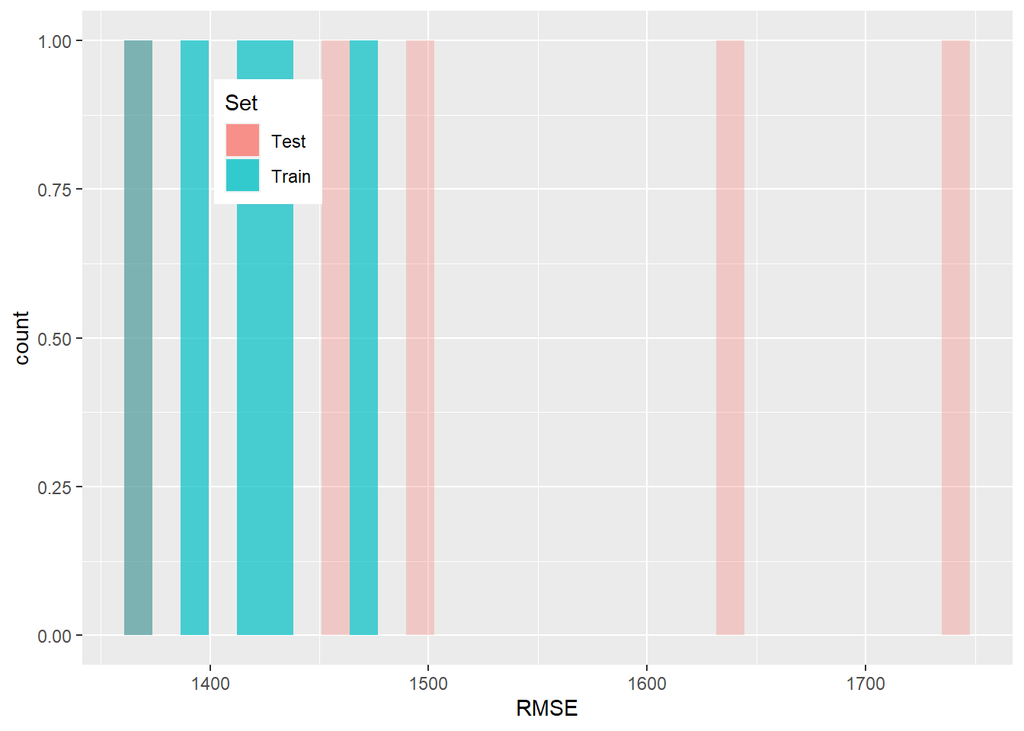

#### T-test for Passing

A t-test was used to see if the sampling of RMSE was expected to be less than $3000 for each the test and training set.

##### Train

```
##
##  One Sample t-test
##
## data:  acc %>% filter(Set == "Train") %>% select(RMSE)
## t = -101.15, df = 4, p-value = 2.864e-08
## alternative hypothesis: true mean is less than 3000
## 95 percent confidence interval:
##      -Inf 1449.651
## sample estimates:
## mean of x
##  1416.271
```

The resulting p-value is very small, which allows us to reject the null hypothesis of the RMSE value being greater than 3000 for the train set.

##### Test

```
##
##  One Sample t-test
##
## data:  acc %>% filter(Set == "Test") %>% select(RMSE)
## t = -21.949, df = 4, p-value = 1.275e-05
## alternative hypothesis: true mean is less than 3000
## 95 percent confidence interval:
##      -Inf 1677.369
## sample estimates:
## mean of x
##  1535.083
```

The resulting p-value is very small, which allows us to reject the null hypothesis of the RMSE value being greater than 3000 for the test set.

#### Model Selection

Since the model with all variables included, confidently meets are requirement, it is selected as the model to use for predicting MonthlyIncome.

# Summary